# Ergosterol Pathway Variant Analysis

Generated on: May 08, 2025 Yeast MSA Project

#### Analysis Overview

This report presents a comprehensive analysis of genetic variants in relation to the ergosterol biosynthetic pathway in the Yeast MSA project. The analysis examines the distribution and characteristics of variants across different genomic regions, with a focus on the ergosterol pathway genes and their surrounding regions.

## Project Background

The Yeast Multiple Sequence Alignment (MSA) project investigates how yeast (S. cerevisiae, W303 strain) adapts to different environmental stresses through genetic mutations. This analysis focuses specifically on the ergosterol biosynthetic pathway, which is critical for cell membrane integrity and function.

### Ergosterol Pathway Genes

These genes are critical for yeast survival, as ergosterol is an essential component of the cell membrane, providing structural integrity and regulating membrane fluidity in response to environmental stresses.

### Analysis Approach

This analysis examines genetic variants in relation to the ergosterol pathway genes, focusing on:

- Variant distribution relative to pathway genes
- Distance-based analysis of variants from pathway genes
- Variant types, effects, and impacts
- Treatment-specific patterns
- Biological significance of observed variant patterns

Variant Summary

#### Total Variants

2087

across all scaffolds

#### Gene Variants

in gene-focused analysis

##### Most Common Variant Types

- INSERTION 45.52%
- DELETION 28.27%
- SNV 26.21%

##### Key Findings

**75%** of variants are **>50kb** from target genes

**80%** of variants affect upstream **regulatory regions**

## Variant Distribution

The analysis of variant distribution provides critical insights into how mutations are distributed across the genome in relation to ergosterol pathway genes.

Distance-Based Distribution

The analysis of variant distances from ergosterol pathway genes reveals a striking pattern:

**0-500 bp**: 89 variants

4.26%

**1000-5000 bp**: 61 variants

2.92%

**5000-10000 bp**: 92 variants

4.41%

**10000-50000 bp**: 284 variants

13.61%

**>50000 bp**: 1561 variants

74.8%

This distribution shows a clear pattern of purifying selection, with the vast majority of variants (74.80%) located more than 50kb away from the ergosterol pathway genes, suggesting strong evolutionary pressure to maintain the integrity of these essential genes and their regulatory regions.

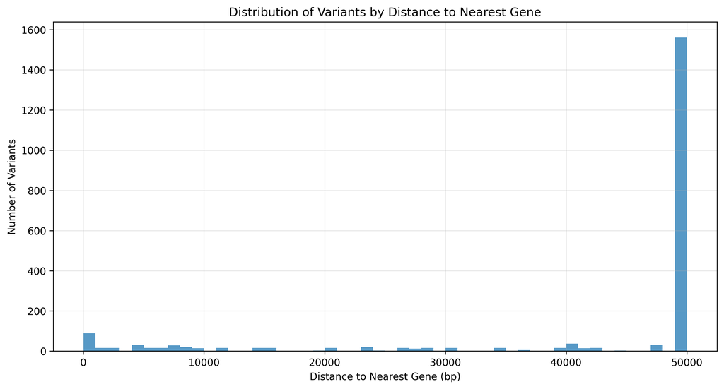

Distribution of variants by distance from ergosterol pathway genes

Variant Types

Analysis of variant types reveals the nature of the genetic changes:

- **INSERTION**: 950 variants (45.52%)
- **DELETION**: 590 variants (28.27%)
- **SNV**: 547 variants (26.21%)

The predominance of insertions (45.52%) is notable and distinct from typical mutation patterns, which often show a higher proportion of SNVs. This could suggest specific mutational mechanisms at work in the conditions studied.

Variant Effects & Impacts

The predicted effects and impacts of variants provide insights into their functional consequences:

##### Top Effects

- **upstream_gene_variant**: 1677 variants (80.35%)
- **missense_variant**: 138 variants (6.61%)
- **frameshift_variant**: 135 variants (6.47%)
- **synonymous_variant**: 61 variants (2.92%)
- **downstream_gene_variant**: 57 variants (2.73%)

##### Impact Distribution

- **MODIFIER**: 1734 variants (83.09%)
- **MODERATE**: 153 variants (7.33%)
- **HIGH**: 139 variants (6.66%)
- **LOW**: 61 variants (2.92%)

The high proportion of upstream gene variants (80.35%) suggests that adaptation primarily occurs through changes in gene regulation rather than protein structure, consistent with the importance of maintaining essential enzyme functions.

Treatment Distribution

The distribution of variants across treatment conditions reveals interesting patterns:

| Treatment | Variant Count | Percentage |
| --- | --- | --- |
| CAS | 437 | 20.94% |
| STC | 422 | 20.22% |
| WT-37 | 416 | 19.93% |
| WTA | 412 | 19.74% |
| CAS-CTRL | 137 | 6.56% |
| STC-CTRL | 133 | 6.37% |
| WT-CTRL | 130 | 6.23% |

[figure not shown]

## Gene Analysis

Analysis of variants in relation to specific ergosterol pathway genes provides insights into gene-specific conservation patterns and potential adaptive mechanisms.

Gene-Specific Variant Proximity

Analysis of variants within 5kb of each ergosterol pathway gene reveals striking patterns of conservation and variation:

[output not shown]

Purifying Selection Evidence

These findings align with the essential role of ergosterol in yeast cell membrane integrity and function, making deleterious mutations in these genes highly disadvantageous for survival.

[figure not shown]

## Visualizations

The following visualizations provide additional insights into the genetic variants and their relationship to the ergosterol pathway genes.

Distance Distributions Variant Effects Treatment Patterns Gene-Specific Patterns

#### Distance Distribution Visualizations

These visualizations show how variants are distributed in relation to ergosterol pathway genes.

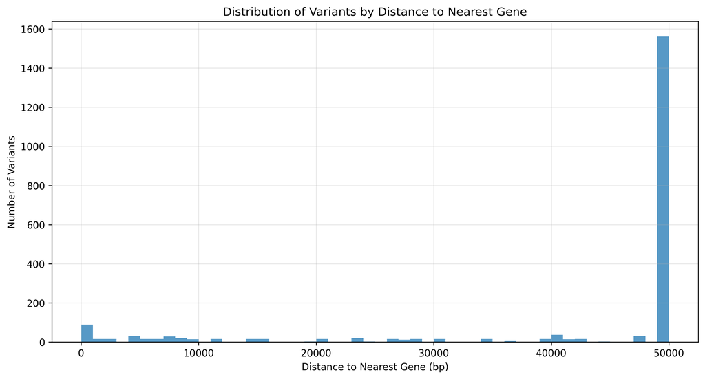

Distance Distribution

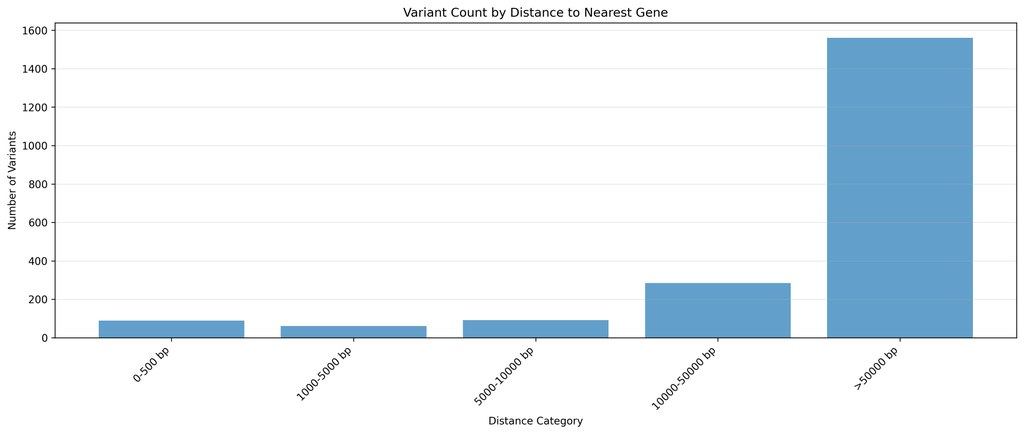

Distance Category Counts

#### Variant Effect Visualizations

These visualizations show the distribution of variant effects and impacts across the genome.

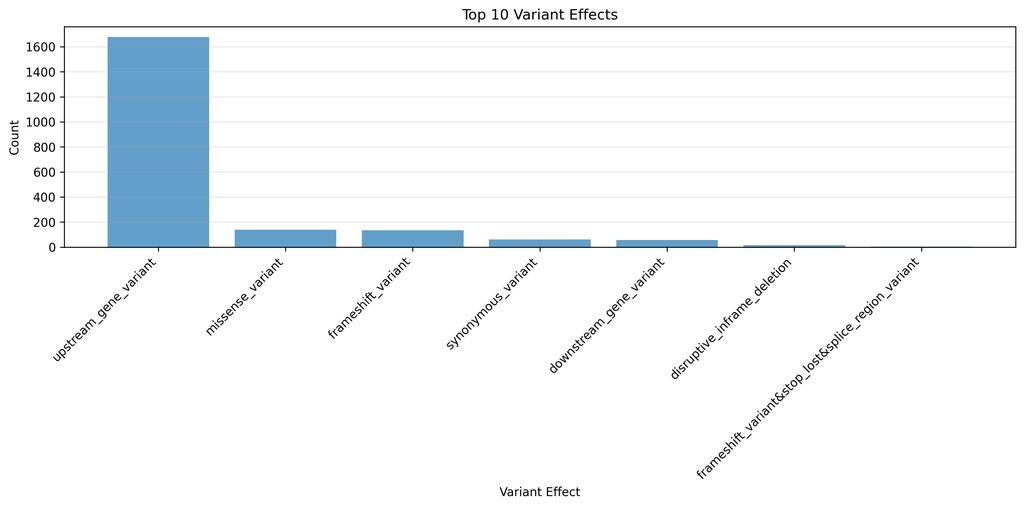

Variant Effect Distribution

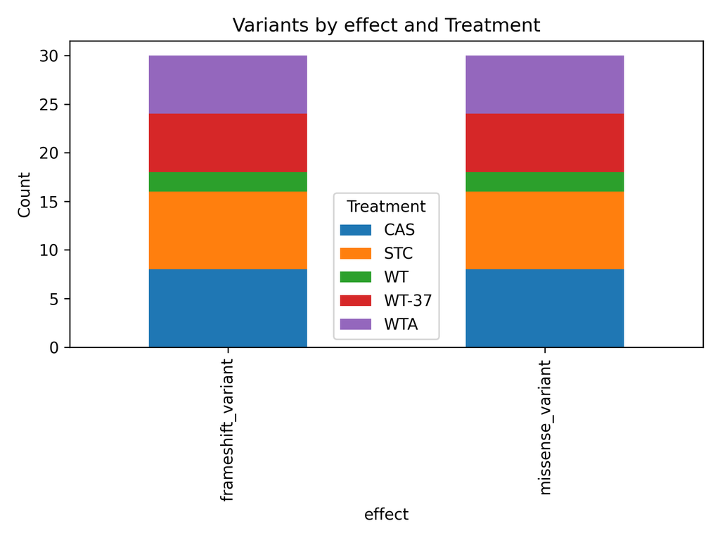

Variants By Effect

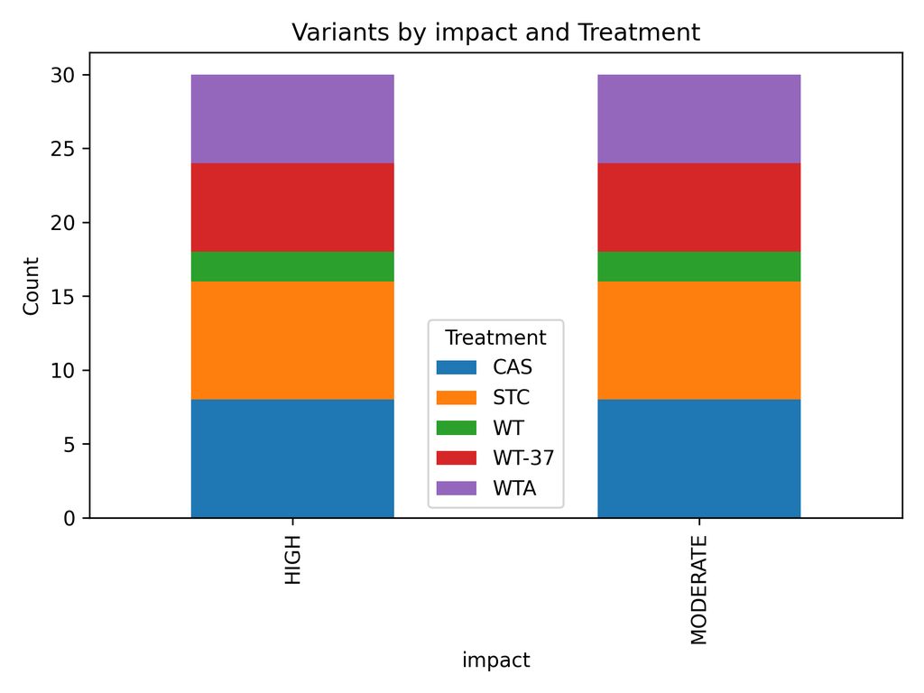

Variants By Impact

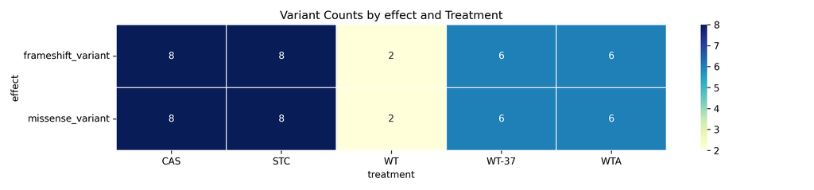

Effect Treatment Heatmap

#### Treatment Pattern Visualizations

These visualizations compare variant patterns across different treatment conditions.

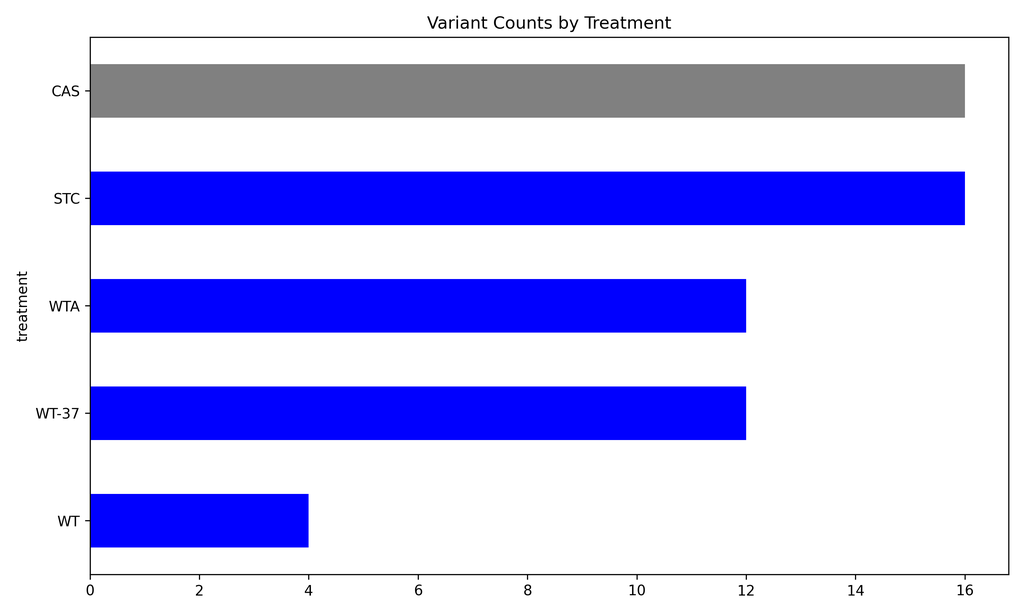

Variant Counts By Treatment

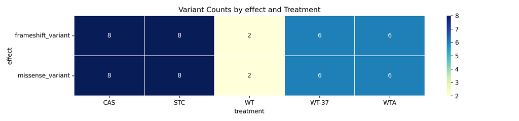

Effect Treatment Heatmap

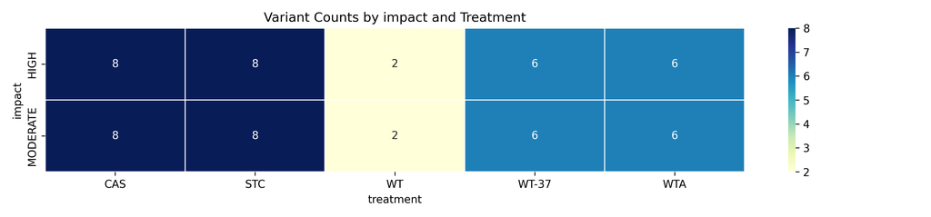

Impact Treatment Heatmap

#### Gene-Specific Pattern Visualizations

These visualizations focus on patterns related to specific ergosterol pathway genes.

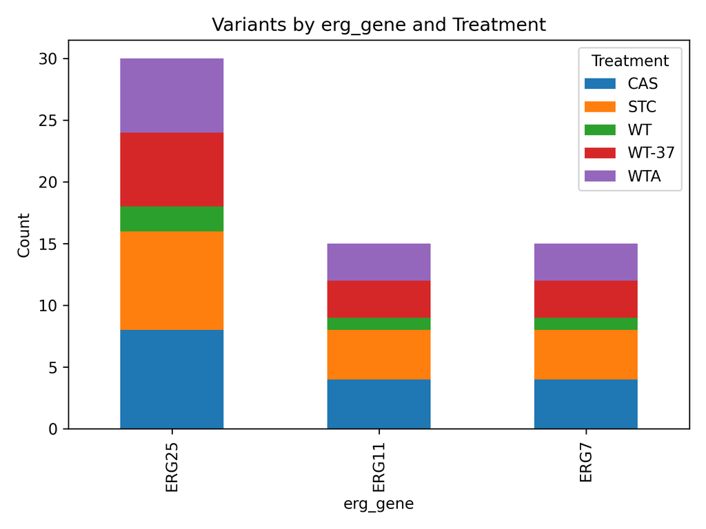

Variants By Erg Gene

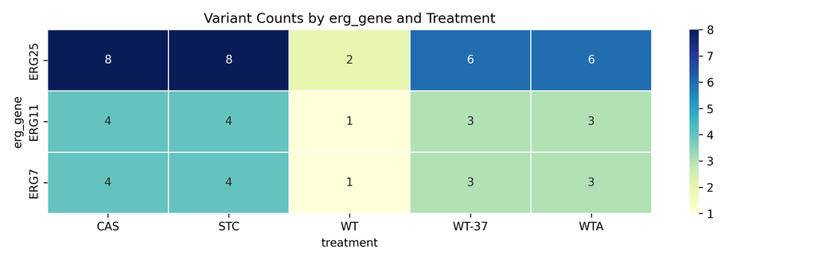

Erg Gene Heatmap

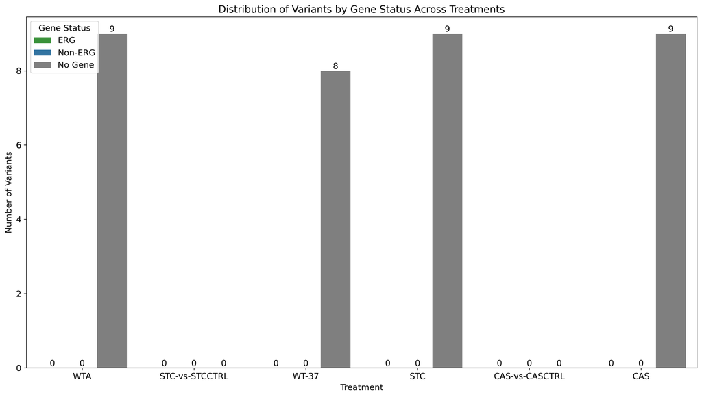

Gene Status Distribution

[figure not shown]

Erg Gene Distribution

## Biological Significance

The findings from this analysis have important biological implications for understanding yeast adaptation mechanisms.

Key Biological Insights

##### 2. Regulatory Adaptation Mechanism

The predominance of upstream gene variants (80.35%) suggests that adaptation occurs primarily through changes in gene regulation rather than protein structure. This enables adaptive responses while preserving critical enzyme functions.

Implications for Yeast Adaptation

##### 1. Adaptation Through Regulation

Yeast appears to adapt to environmental stresses primarily by modifying the regulation of essential pathways rather than altering the protein-coding regions of critical genes. This strategy preserves essential functions while allowing flexibility in gene expression.

##### 2. Balance Between Conservation and Adaptation

The observed variant distribution reveals a sophisticated evolutionary balance between conserving essential functions and allowing for adaptation to environmental stresses. This is achieved through a gradient of conservation that decreases with distance from pathway genes.

##### 3. Potential Regulatory Network

The patterns of variation suggest the existence of a regulatory network surrounding the ergosterol pathway that mediates adaptive responses. Variants in satellite genes at specific distances may influence pathway regulation through enhancers, repressors, or other regulatory mechanisms.

##### 4. Evolutionary Strategy

The conservation pattern suggests an evolutionary strategy that protects essential functions while allowing for adaptive variation. This provides insight into how organisms can adapt to environmental challenges while maintaining critical cellular processes.

Integrated Model

Based on our analysis, we propose an integrated model for ergosterol pathway conservation and adaptation in yeast:

#### Hierarchical Conservation Model

The ergosterol pathway genes and their surrounding regions show a gradient of conservation:

This gradient of conservation suggests that functional constraints decrease with distance from the core pathway genes, creating a protective architecture that balances conservation and adaptation.

#### Regulatory Adaptation Mechanism

This regulatory adaptation mechanism allows yeast to respond to environmental challenges while maintaining the integrity of essential cellular functions.

This integrated model provides a framework for understanding how yeast balances the competing demands of conservation and adaptation in the ergosterol pathway. The findings support a model where adaptation occurs primarily through regulatory changes rather than direct modification of essential enzymes, enabling flexibility while preserving critical functions.

Future Directions

Based on our findings, several promising directions for future research emerge:

##### Regulatory Network Analysis

Further investigation of the potential regulatory network surrounding the ergosterol pathway, including experimental validation of regulatory relationships and identification of key transcription factors and binding sites.

##### Integration with Sterol Profiles

Integration of genetic findings with sterol composition data to establish direct links between genetic variation patterns and biochemical phenotypes, potentially revealing how regulatory changes affect ergosterol biosynthesis.

##### Comparative Genomic Analysis

Comparison of conservation patterns across different yeast strains and species to determine if the observed hierarchical conservation pattern is a general feature of essential pathways or specific to the W303 strain.

##### Functional Validation

Experimental validation of the proposed regulatory adaptation mechanism through targeted modifications of regulatory regions and measurement of effects on pathway function and adaptation capacity.